# Chromium database for CoralOx

Marcos Fontela

19 noviembre, 2021

I started searching for Chromium (**Cr**) data in [GEOTRACES electronic atlas](https://www.egeotraces.org/). Nothing at all. It is based in *GEOTRACES Intermediate Data Product 2021*. There are few sections (5, a in Atlantic and 3 in Arctic) with the concentration of total **particulate chromium** determined by filtration from a water sampling bottle. No data for dissolved Cr.

The same happens in *PANGAEA*, with almost no dissolved measurements. Most of them are over the particulate fraction and/or not in seawater. The only one available was these old measurements in the northwest Pacific.

- Demina, Lyudmila L; Atnashev, Vitaly B (1989): Concentrations of dissolved and particulate heavy metals in waters above the northwestern slope of the Paramushir Island (Sea of Okhotsk). PANGAEA, https://doi.org/10.1594/PANGAEA.757685, Supplement to: Demina, LL; Atnashev, VB (1989): Anomalous behavior of metals in the vicinity of an underwater gas vent off Paramushir Island, Sea of Okhotsk. Oceanology, 29(6), 708-714

```r
# pangaear::pg_search(query = "dissolved chromium seawater")%>% relocate(citation)
#Most of them are in particulate or not even in seawater
#The most promising one:
Demina_doi="10.1594/PANGAEA.757685" #https://doi.pangaea.de/10.1594/PANGAEA.757685
Demina<-as.data.frame(pangaear::pg_data(doi=Demina_doi)[[1]][["data"]])%>%
  mutate(ref="Demina1989")
rm(Demina_doi) #no longer needed
```

- Bonnand P, James RH, Parkinson IJ, et al (2013) The chromium isotopic composition of seawater and marine carbonates. Earth Planet Sci Lett 382:10–20. https://doi.org/https://doi.org/10.1016/j.epsl.2013.09.001
- Scheiderich K, Amini M, Holmden C, Francois R (2015) Global variability of chromium isotopes in seawater demonstrated by Pacific, Atlantic, and Arctic Ocean samples. Earth Planet Sci Lett 423:87–97. https://doi.org/https://doi.org/10.1016/j.epsl.2015.04.030
- Rickli J, Janssen DJ, Hassler C, et al (2019) Chromium biogeochemistry and stable isotope distribution in the Southern Ocean. Geochim Cosmochim Acta 262:188–206. https://doi.org/https://doi.org/10.1016/j.gca.2019.07.033
- Moos SB, Boyle EA (2019) Determination of accurate and precise chromium isotope ratios in seawater samples by MC-ICP-MS illustrated by analysis of SAFe Station in the North Pacific Ocean. Chem Geol 511:481–493. https://doi.org/https://doi.org/10.1016/j.chemgeo.2018.07.027
- Janssen DJ, Rickli J, Quay PD, et al (2020) Biological Control of Chromium Redox and Stable Isotope Composition in the Surface Ocean. Global Biogeochem Cycles 34:e2019GB006397. https://doi.org/https://doi.org/10.1029/2019GB006397
- Janssen DJ, Rickli J, Abbott AN, et al (2021) Release from biogenic particles, benthic fluxes, and deep water circulation control Cr and δ53Cr distributions in the ocean interior. Earth Planet Sci Lett 574:117163. https://doi.org/https://doi.org/10.1016/j.epsl.2021.117163

Some of them can be directly downloaded from [Zenodo](https://zenodo.org/), the *Scheiderich2015*, the *Bonnand2013* and the *MoosBoyle2019* data were manually transferred from the Tables of the article into an Excel file. Some time after the processing I realized that *Bonnand2013* data is included in the *Scheiderich2015* file

## Download data

```r
#I download some files directly from Zenodo
#The first time you run the markdown file, the files are downloaded.
if (!dir.exists("DATA/Rickli2019")) { #But don't if they already exists.
# https://zenodo.org/record/3250980
dir.create("DATA/Rickli2019", showWarnings = FALSE)
zen4R::download_zenodo(path = "DATA/Rickli2019", "10.5281/zenodo.3250980")
}

if (!dir.exists("DATA/Janssen2020")) {
#https://zenodo.org/record/3560082
dir.create("DATA/Janssen2020", showWarnings = FALSE)
zen4R::download_zenodo(path = "DATA/Janssen2020", "10.5281/zenodo.3560082")
}

if (!dir.exists("DATA/Janssen2021")) {
#https://zenodo.org/record/5408613
dir.create("DATA/Janssen2021", showWarnings = FALSE)
zen4R::download_zenodo(path = "DATA/Janssen2021", "10.5281/zenodo.5408613")
}
```

## Load data files

```r
Bonnand2013 <- read_excel("DATA/Bonnand2013.xlsx")%>%
  mutate(ref="Bonnand2013")

Scheiderich2015 <- read_excel("DATA/Scheiderich2015.xlsx")%>%
  mutate(ref="Scheiderich2015")

Rickli2019 <- read_csv("DATA/Rickli2019/ace_chromium_isotope_concentration.csv", show_col_types = FALSE)%>% #perfect
  mutate(ref="Rickli2019")

MoosBoyle2019 <- read_excel("DATA/MoosBoyle2019.xlsx", skip = 1)%>%
  mutate(ref="MoosBoyle2019")

Janssen2020 <- read_excel("DATA/Janssen2020/Janssen_etal_KM1713_Cr_Data.xlsx",
    sheet = "Sheet1", range = "A2:O96") #FAIL. Needs a lot of pre-processing

Janssen2021 <- read_delim("DATA/Janssen2021/Janssen_etal_d53CrData_Zenodo.txt",
    delim = "\t", escape_double = FALSE,
    trim_ws = TRUE)%>% #Not perfect but easy to solve afterwards.
  mutate(ref="Janssen2021")
#fix colnames:
colnames(Janssen2021)[8]="neutral_density"
colnames(Janssen2021)[11]="53Cr"
colnames(Janssen2021)[12]="error53Cr"
#delete the first two rows (they are empty or have units) and convert to numeric
Janssen2021=Janssen2021[-(1:2),]
Janssen2021[,c(3:15)]=sapply(Janssen2021[, c(3:15)], as.numeric)

#NEW Janssen 2020 after manual processing
Janssen2020 <- read_excel("DATA/Janssen2020.xlsx",
    col_types = c("text", "numeric", "numeric",
        "numeric", "text", "numeric", "text",
        "numeric", "numeric", "numeric",
        "numeric", "numeric", "numeric", "numeric",
        "numeric", "numeric", "numeric", "numeric",
        "numeric", "numeric", "numeric"), skip = 1, na = "NA")%>%
  mutate(ref="Janssen2020")
```

## Merge different sources

One of the problems, [Cr] does not share units: *Demina microg/L* Bonnand2013 in in nM (= nmol/L) *Scheid2015 in ng/kg* Rickli2019 in nmol/kg *MoosBoyle2019 in nmol/kg* Janssen2020 in nmol/kg and ng/kg *Janssen2021 in nmol/kg

for what I see, the units in **nmol/kg** are the standard

```r
#Demina microg/L
#Bonnand2013 in in nM (= nmol/L)
#Scheid2015 in ng/kg
#Rickli2019 in nmol/kg
#Janssen2020 in nmol/kg and ng/kg
#Janssen2021 in nmol/kg

#Demina
#2steps: microg/L to migrog/kg (I need a density for that... 1025 kg/m3 as an approach)
Demina$`Cr [nmol_kg]`=Demina$`Cr [µg/l] (dissolved, Atomic absorption ...)`/1.025
#microg/kg to micromol/kg
Demina$`Cr [nmol_kg]`=Demina$`Cr [nmol_kg]`/26.982
#micromol (10^-6)/kg to nmol(10^-9)/kg
Demina$`Cr [nmol_kg]`=Demina$`Cr [nmol_kg]`*1000
#Inside Scheid2015 there is the Bonnand data in ng/kg. Molar mass Chromium: 26.982 g/mol
Scheiderich2015<-mutate(Scheiderich2015, `Cr [nmol_kg]`= `Cr (ng/kg)`/26.982)
```

The next step is to merge the databases in a single one

```r
# Longitude, Latitude, Station, Depth, Cr [nmol_kg], d53Cr
colnames(Bonnand2013)[1]="Station"
colnames(Bonnand2013)[4]="Depth"
colnames(Demina)[5]="Depth"
colnames(Scheiderich2015)[2]="Depth"
colnames(Scheiderich2015)[7]="Latitude"
colnames(Scheiderich2015)[8]="Longitude"
colnames(Rickli2019)[2]="Latitude"
colnames(Rickli2019)[3]="Longitude"
colnames(Rickli2019)[7]="Depth"
colnames(Rickli2019)[9]="d53Cr"
colnames(Rickli2019)[8]="Cr [nmol_kg]" #Janssen mode
colnames(Janssen2020)[14]="d53Cr"
colnames(Janssen2020)[8]="neutral_density"
colnames(Janssen2020)[13]="NO3"
colnames(Janssen2021)[11]="d53Cr"
colnames(Janssen2021)[10]="Cr [nmol_kg]"


Reduce(
  intersect,list(
    colnames(Scheiderich2015),
    colnames(Janssen2020),
    colnames(Demina),
    colnames(Bonnand2013),
    colnames(Janssen2021),
    colnames(Rickli2019))) #All the samples have lon-lat-depth (and ref) in common
```

```
## [1] "Depth"     "Latitude"  "Longitude" "ref"
```

```r
Janssen2020$Station=as.character(Janssen2020$Station)

Crdb<-Reduce(
    full_join,list(
        (Scheiderich2015),
        (Janssen2020),
        (Demina),
        (Bonnand2013),
        (Janssen2021),
        (Rickli2019)))
Crdb<-Crdb%>%
  relocate(ref, Longitude, Latitude, Depth)
```

Does it have sense for you? I hope it!

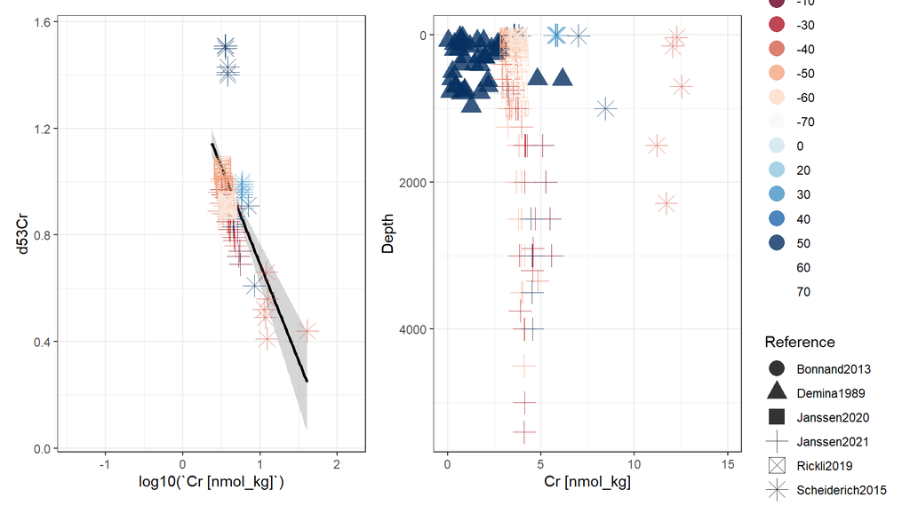

I guess that now, you can do the conversion [Cr] –> d53Cr… but there is a big “problem”: practically all this data already have d53Cr values associated. Only *Demina1989* does not have it… so very few “new” d53Cr points.(~ around 40)

## Export

Export the new database called **Crdb** in a worksheet.

```r
write.table(Crdb, "DATA/Cr_CoralOX_db.csv", row.names = FALSE)
```